# Use CryptDiftR to replicate Biased drift paper

Ed Morrissey

2018-03-05

First load CryptDriftR.

```r
library(CryptDriftR)
```

Next we load the data from Vermeulen, Morrissey et al Science 2013.

```r
data(PulseChaseData)
ls()
```

```
#> [1] "data_Colon_LGR5CreER_WT"     "data_Colon_LGR5CreER_p53"
#> [3] "data_DSSColon_LGR5CreER_WT"  "data_DSSColon_LGR5CreER_p53"
#> [5] "data_SI_ahCreER_APChet"      "data_SI_ahCreER_APChom"
#> [7] "data_SI_ahCreER_KRAS"        "data_SI_ahCreER_WT"
#> [9] "oldLC"
```

This data set comprises all 8 pulse chase data sets used in the paper.

# Small intestine data analysis

## Wild type data

Fit the data with the neutral drift model.

```r
# Get time points from colnames
time_interval = data_SI_ahCreER_WT %>% colnames() %>% as.numeric()
# Fit model
fit_out_WT   = fitNeutralDrift(data_SI_ahCreER_WT, time_interval, n_par_chains = 2)
```

The model is fit using MCMC, so it’s a good idea to check everything has gone well. This tends to not be a problem for this code, but worth checking.

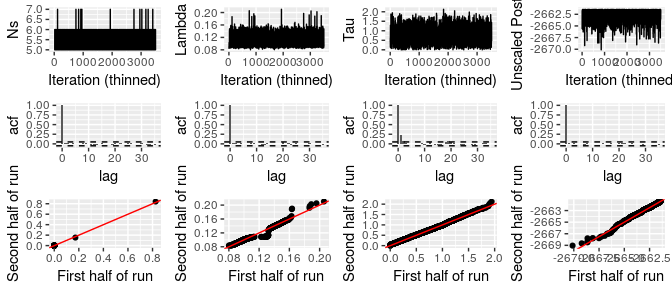

```r
pp_convergence = plotsConvergence_Neutral(fit_out_WT)
plot(pp_convergence)
```

We can look at the parametres that were inferred.

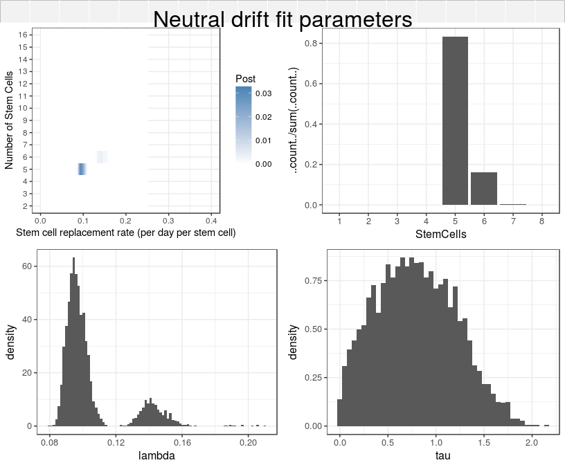

```r
pp_posterior = plotPosterior_Neutral(fit_out_WT)
plot(pp_posterior)
```

We can also access the optimal fit (MAP estimate is used for this).

```r
print(fit_out_WT$MAP_est)
```

```
#> $lambda
#> [1] 0.09607549
#>
#> $N
#> [1] 5
#>
#> $tau
#> [1] 0.8631263
```

It’s also possible to plot the data with the optimal fit overlaid.

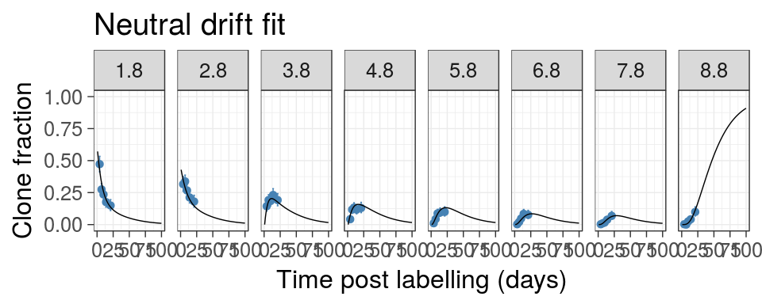

```r
plotsNeutralDrift_Fit(fit_out_WT)
```

## Mutant pulse chase data

Next we fit the biased drift model to the KRAS data.

```r
time_interval = data_SI_ahCreER_KRAS %>% colnames() %>% as.numeric()
# We use the WT parameters inferred from the WT data
fit_out_mut   = fitBiasedDrift(data_SI_ahCreER_KRAS, time_interval, WT_params = fit_out_WT$MAP_est, n_par_chains = 2)
```

Again we can check the convergence.

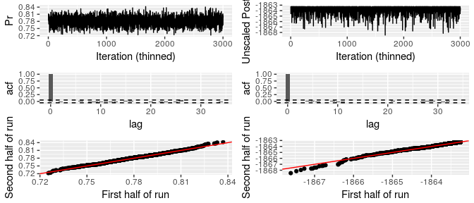

```r
pp_convergence =  plotsConvergence_Biased(fit_out_mut)
plot(pp_convergence)
```

We can plot the inferred parameter.

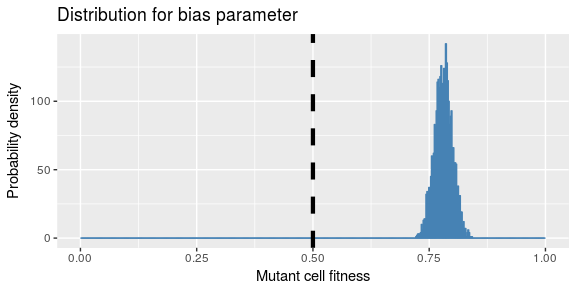

```r
pp_posterior = plotPosterior_Pr(fit_out_mut)
plot(pp_posterior)
```

And calculate the estimate of the paramater

```r
print(fit_out_mut$Pr_quant)
```

```
#>      2.5%       50%     97.5%
#> 0.7431820 0.7809916 0.8187082
```

We can also plot the fit

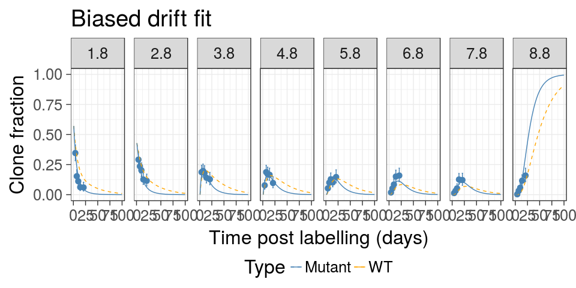

```r
pp_KRAS = plotsBiasDrift_Fit(fit_out_mut)
plot(pp_KRAS)
```

We can analyse the APC mutant data sets.

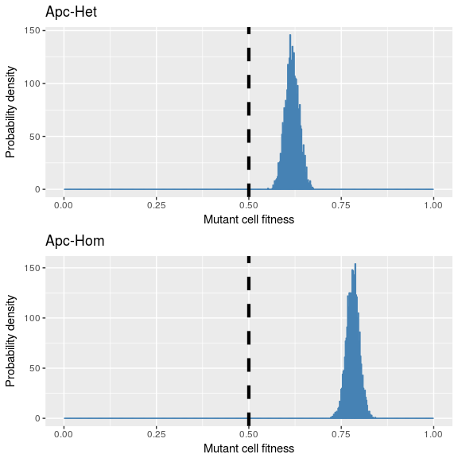

```r
time_interval = data_SI_ahCreER_APChet %>% colnames() %>% as.numeric()
fit_out_het   = fitBiasedDrift(data_SI_ahCreER_APChet, time_interval, WT_params = fit_out_WT$MAP_est, n_par_chains = 2)
time_interval = data_SI_ahCreER_APChom %>% colnames() %>% as.numeric()
fit_out_hom   = fitBiasedDrift(data_SI_ahCreER_APChom, time_interval, WT_params = fit_out_WT$MAP_est, n_par_chains = 2)
pp_het = plotPosterior_Pr(fit_out_het) + ggtitle("Apc-Het")
pp_hom = plotPosterior_Pr(fit_out_hom) + ggtitle("Apc-Hom")
grid.arrange(pp_het, pp_hom)
```

# Colon data analysis

First we get the neutral drift parameters for colon

```r
time_interval    = data_Colon_LGR5CreER_WT %>% colnames() %>% as.numeric()
fit_out_colon_WT = fitNeutralDrift(data_Colon_LGR5CreER_WT, time_interval, n_par_chains = 2)
print(fit_out_colon_WT$MAP_est)
```

```
#> $lambda
#> [1] 0.2633074
#>
#> $N
#> [1] 7
#>
#> $tau
#> [1] 2.135447
```

## Effect of p53

Next we analyse the effect of p53 mutation on colonic stem cells.

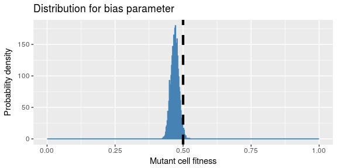

```r
time_interval   = data_Colon_LGR5CreER_p53 %>% colnames() %>% as.numeric()
fit_out   = fitBiasedDrift(data_Colon_LGR5CreER_p53, time_interval, WT_params = fit_out_colon_WT$MAP_est, n_par_chains = 2)
pp_Pr_p53 = plotPosterior_Pr(fit_out)
plot(pp_Pr_p53)
```

## Colitis

We calculate neutral drift parameters on a colitis background.

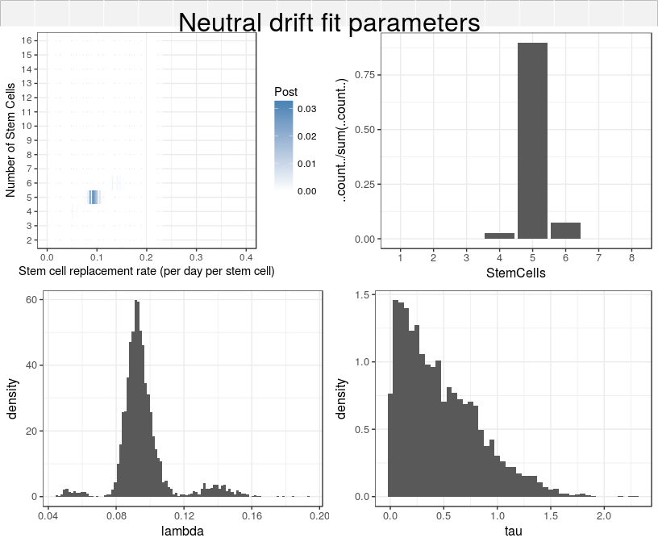

```r
time_interval   = data_DSSColon_LGR5CreER_WT %>% colnames() %>% as.numeric()
fit_out   = fitNeutralDrift(data_DSSColon_LGR5CreER_WT, time_interval, n_par_chains = 2)
pp_post = plotPosterior_Neutral(fit_out)
plot(pp_post)
```

And next we estimate Pr for p53 mutant stem cells with a colitis background.

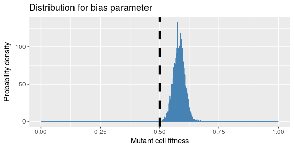

```r
time_interval = data_DSSColon_LGR5CreER_p53 %>% colnames() %>% as.numeric()
fit_out_mut   = fitBiasedDrift(data_DSSColon_LGR5CreER_p53, time_interval, WT_params = fit_out$MAP_est, n_par_chains = 2)
pp_Pr_p53     = plotPosterior_Pr(fit_out_mut)
plot(pp_Pr_p53)
```